# Trabajo Final Business Performance

Roman Katz

12/3/2020

# Trabajo Final : Business Performance

### Ejercicio 1

1. Importar bases de datos en R y hacer las comprobaciones pertinentes. Importante describir y explicar cada paso en el Script.

```r
 data <- read.csv('Dataset_Compradores.csv',header = T)
str(data)
```

```
## 'data.frame':    10000 obs. of  14 variables:
##  $ RowNumber      : int  1 2 3 4 5 6 7 8 9 10 ...
##  $ CustomerId     : int  15634602 15647311 15619304 15701354 15737888 15574012 15592531 15656148 15792365 15592389 ...
##  $ Surname        : chr  "Hargrave" "Hill" "Onio" "Boni" ...
##  $ CreditScore    : int  619 608 502 699 850 645 822 376 501 684 ...
##  $ Geography      : chr  "France" "Spain" "France" "France" ...
##  $ Gender         : chr  "Female" "Female" "Female" "Female" ...
##  $ Age            : int  42 41 42 39 43 44 50 29 44 27 ...
##  $ Tenure         : int  2 1 8 1 2 8 7 4 4 2 ...
##  $ Balance        : num  0 83808 159661 0 125511 ...
##  $ NumOfProducts  : int  1 1 3 2 1 2 2 4 2 1 ...
##  $ HasCrCard      : int  1 0 1 0 1 1 1 1 0 1 ...
##  $ IsActiveMember : int  1 1 0 0 1 0 1 0 1 1 ...
##  $ EstimatedSalary: num  101349 112543 113932 93827 79084 ...
##  $ Exited         : int  1 0 1 0 0 1 0 1 0 0 ...
```

```r
summary(data)
```

```
##    RowNumber       CustomerId         Surname           CreditScore
##  Min.   :    1   Min.   :15565701   Length:10000       Min.   :350.0
##  1st Qu.: 2501   1st Qu.:15628528   Class :character   1st Qu.:584.0
##  Median : 5000   Median :15690738   Mode  :character   Median :652.0
##  Mean   : 5000   Mean   :15690941                      Mean   :650.5
##  3rd Qu.: 7500   3rd Qu.:15753234                      3rd Qu.:718.0
##  Max.   :10000   Max.   :15815690                      Max.   :850.0
##   Geography            Gender               Age            Tenure
##  Length:10000       Length:10000       Min.   :18.00   Min.   : 0.000
##  Class :character   Class :character   1st Qu.:32.00   1st Qu.: 3.000
##  Mode  :character   Mode  :character   Median :37.00   Median : 5.000
##                                        Mean   :38.92   Mean   : 5.013
##                                        3rd Qu.:44.00   3rd Qu.: 7.000
##                                        Max.   :92.00   Max.   :10.000
##     Balance       NumOfProducts    HasCrCard      IsActiveMember
##  Min.   :     0   Min.   :1.00   Min.   :0.0000   Min.   :0.0000
##  1st Qu.:     0   1st Qu.:1.00   1st Qu.:0.0000   1st Qu.:0.0000
##  Median : 97199   Median :1.00   Median :1.0000   Median :1.0000
##  Mean   : 76486   Mean   :1.53   Mean   :0.7055   Mean   :0.5151
##  3rd Qu.:127644   3rd Qu.:2.00   3rd Qu.:1.0000   3rd Qu.:1.0000
##  Max.   :250898   Max.   :4.00   Max.   :1.0000   Max.   :1.0000
##  EstimatedSalary         Exited
##  Min.   :    11.58   Min.   :0.0000
##  1st Qu.: 51002.11   1st Qu.:0.0000
##  Median :100193.91   Median :0.0000
##  Mean   :100090.24   Mean   :0.2037
##  3rd Qu.:149388.25   3rd Qu.:0.0000
##  Max.   :199992.48   Max.   :1.0000
```

```r
length(data) #14 columnas
```

```
## [1] 14
```

```r
dim(data)
```

```
## [1] 10000    14
```

```r
data$RowNumber<- NULL
data$Exited<- NULL
```

En el codigo anterior hemos cargado la base de datos y realizamos una primera aproximacion a los datos contenidos a traves de diferentes comandos para ver la estructura y forma de los datos. A partir de los comandos realizados pudimos observar 3 columnas tipo caracter relacionadas a apellidos, pais de procedencia y genero. Tambien se observa que el resto de las columnas son de tipo cuantitativo. Con la funcion summary pudimos visualizar algunos parametros principales, como ser el rango de edades de nuestro dataset, el rango en el salario estimado y el credit score. Tambien de todas las variables cuantitativas pudimos observar los cuartiles, su media y su mediana. Con las funciones Length y DIM, pudimos obtener las dimensiones de nuestros datos. Y por ultimo eliminamos la columna ‘Row Number’ que contenia los indices y no proveia informacion relevante para el analisis.

### Ejercicio 2

2. Describir de manera grafica y estadistica las variables de la base de datos. Importante explicar la eleccion de los graficos asi como lo que se observa en los descriptivos estadisticos. *Puntos importantes: tendencia central, dispersion, forma de la distribucion (normalidad),* valores perdidos, valores extremos

## BARRAS

A partir de la base de datos de 10000 observaciones, hemos realizado distintos gráficos para cada una de las variables, iniciando con los gráficos de barras para las variables categóricas. Luego se han realizado histogramas para aquellas variables cuantitativas.

### Gráfico Barras – Geografía y Genero

Iniciamos observando la variable geografía donde pudimos concluir que la data está concentrada en tres países siendo Francia con 5,014, el que lidera la cantidad de datos, luego Alemania con 2,509 y finalmente España con 2,477, siendo estos dos últimos muy similares. Tomando el gráfico anterior, quisimos observar la distribución por genero en cada país, para poder tener mayores detalles de éste, hemos realizado una relación entre la cantidad de hombre y mujeres donde vemos la tendencia en los tres países frente a la tendencia global, concluyendo lo siguiente: - Hay más hombres que mujeres, teniendo un ratio de 0.83 a nivel global. - El conteo de Francia es la muestra principal ya que tiene mayor cantidad de datos y por lo tanto su ratio toma mayor importancia en el promedio global. - Alemania, es el país que más se acerca a una relacion 1:1, ya que resulto tener un ratio de 0.906. - España es el país con mayor diferencia entre hombres y mujeres, siendo éste 0.78.

```r
library(ggthemes)
library(psych)
```

```r
p <- ggplot(data)

table(data$Geography)
```

```
##
##  France Germany   Spain
##    5014    2509    2477
```

```r
by(data$NumOfProducts,data$Gender,describe)
```

```
## data$Gender: Female
##    vars    n mean  sd median trimmed mad min max range skew kurtosis   se
## X1    1 4543 1.54 0.6      1    1.49   0   1   4     3 0.85     0.89 0.01
## ------------------------------------------------------------
## data$Gender: Male
##    vars    n mean   sd median trimmed mad min max range skew kurtosis   se
## X1    1 5457 1.52 0.56      1    1.49   0   1   4     3 0.63     0.17 0.01
```

```r
by(data$NumOfProducts,data$Geography,describe)
```

```
## data$Geography: France
##    vars    n mean   sd median trimmed mad min max range skew kurtosis   se
## X1    1 5014 1.53 0.57      1     1.5   0   1   4     3 0.68     0.54 0.01
## ------------------------------------------------------------
## data$Geography: Germany
##    vars    n mean   sd median trimmed mad min max range skew kurtosis   se
## X1    1 2509 1.52 0.62      1    1.45   0   1   4     3 1.01     1.12 0.01
## ------------------------------------------------------------
## data$Geography: Spain
##    vars    n mean   sd median trimmed  mad min max range skew kurtosis   se
## X1    1 2477 1.54 0.56      2    1.51 1.48   1   4     3 0.52    -0.17 0.01
```

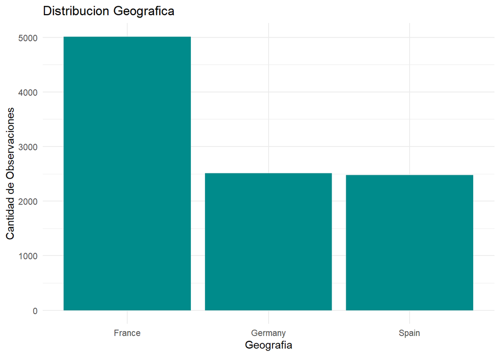

```r
p+geom_bar(mapping =aes(x=Geography),fill = 'cyan4')+theme_minimal()+labs(title='Distribucion Geografica',y='Cantidad de Observaciones',x='Geografia')
```

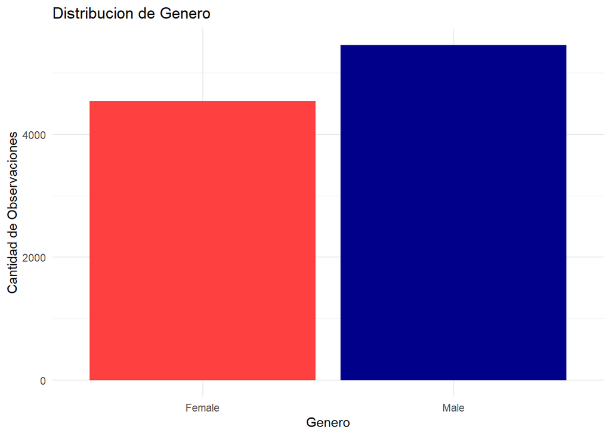

```r
p+geom_bar(mapping =aes(Gender),fill=c('Female'='brown1','Male'='blue4'))+theme_minimal()+labs(title='Distribucion de Genero',y='Cantidad de Observaciones',x='Genero')
```

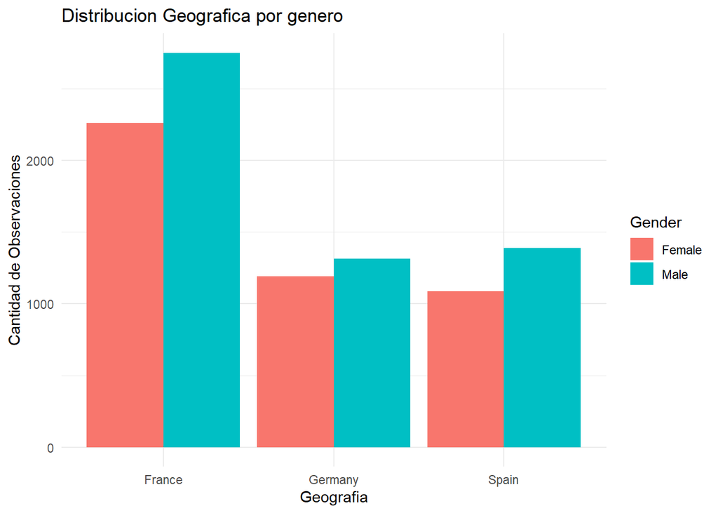

```r
p+geom_bar(mapping =aes(Geography,fill=Gender),position = 'dodge')+theme_minimal()+labs(title='Distribucion Geografica por genero',y='Cantidad de Observaciones',x='Geografia')
```

```r
hombres <- filter(data, data$Gender=='Male')
mujeres <- filter(data, data$Gender=='Female')
hombres_francia <- filter(hombres,hombres$Geography=='France')
hombres_Spain <- filter(hombres,hombres$Geography=='Spain')
hombres_Germany <- filter(hombres,hombres$Geography=='Germany')
mujeres_francia <- filter(mujeres,mujeres$Geography=='France')
mujeres_Spain <- filter(mujeres,mujeres$Geography=='Spain')
mujeres_Germany <- filter(mujeres,mujeres$Geography=='Germany')
ratio_global<- data.frame(c(count(mujeres)/count(hombres),count(mujeres_francia)/count(hombres_francia),count(mujeres_Spain)/count(hombres_Spain),count(mujeres_Germany)/count(hombres_Germany)))
ratio_global <-rename(ratio_global,'Global'=n,'France'=n.1,'Spain'=n.2,'Germany'=n.3)
ratio_global
```

```
##      Global    France     Spain  Germany
## 1 0.8325087 0.8212859 0.7845821 0.906535
```

### Gráfico de Barras – Number of Products y Genero.

En este grafico, podemos conocer la tendencia de la cantidad de productos que tiene cada cliente donde concluimos que la media es 1.53 productos con una sd de 0.58 por lo tanto se puede concluir que la mayoría de la población cuenta con 1 y 2 productos. A partir de esta conclusión, observamos que el numero de hombres que poseen 1 o 2 productos es mayor que el de mujeres, sin embargo conforme aumenta el numero de productos, a partir de tres, la tendencia se invierte ligeramente (considerando únicamente la muestra que estamos analizando).

```r
library(psych)
describe(data$NumOfProducts)
```

```
##    vars     n mean   sd median trimmed mad min max range skew kurtosis   se
## X1    1 10000 1.53 0.58      1    1.49   0   1   4     3 0.75     0.58 0.01
```

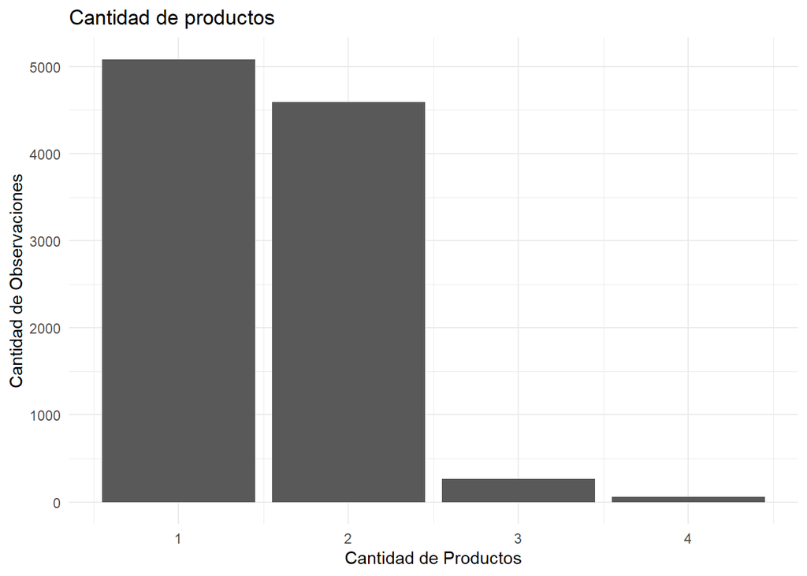

```r
p+geom_bar(mapping = aes(NumOfProducts))+theme_minimal()+labs(title='Cantidad de productos',y='Cantidad de Observaciones',x='Cantidad de Productos')
```

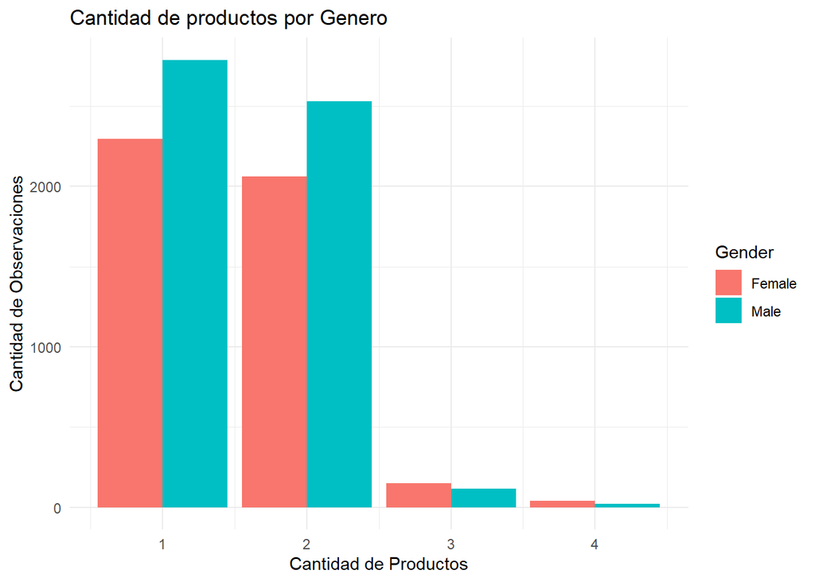

```r
p+geom_bar(mapping = aes(NumOfProducts,fill=Gender),position = 'dodge')+theme_minimal()+labs(title='Cantidad de productos por Genero',y='Cantidad de Observaciones',x='Cantidad de Productos')
```

### Gráfico de Barras – Active Members

Del total de nuestra base de observables, podemos detectar que hay un gran numero de personas inactivas, analizando la variable, obtuvimos que la media es 0.52, siendo mayor el numero de personas con status activo. Si lo vemos por geografía, podemos observar que están distribuidos similarmente en relación a la tendencia general de los 3 países.

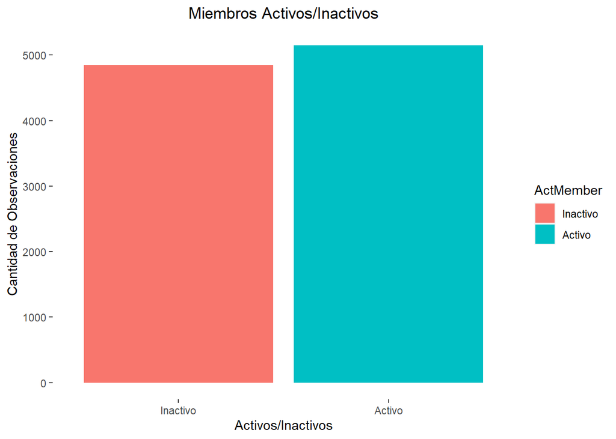

```r
library(ggthemes)
data2 <- data
ActMember <- factor(data$IsActiveMember,levels = c(0,1),labels = c('Inactivo','Activo'))
data2['IsActiveMember'] <- ActMember
p <- ggplot(data)

library(psych)

p2 <- ggplot(data2)

p2+geom_bar(mapping = aes(IsActiveMember,fill=ActMember))+theme(plot.title=element_text(hjust = 0.5),panel.background = element_rect(fill="white"))+labs(title='Miembros Activos/Inactivos',y='Cantidad de Observaciones',x='Activos/Inactivos')
```

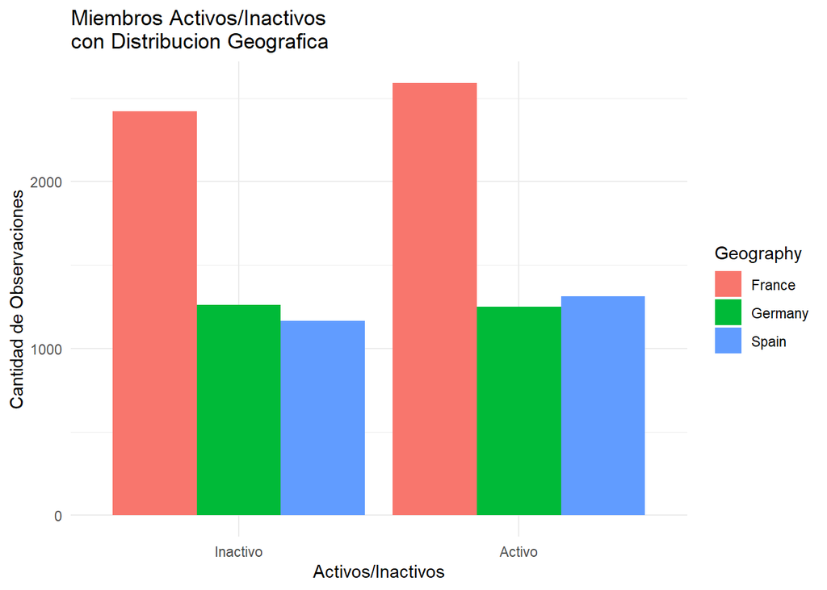

```r
p2+geom_bar(mapping = aes(IsActiveMember,fill=Geography),position = 'dodge')+theme_minimal()+labs(title='Miembros Activos/Inactivos \ncon Distribucion Geografica',y='Cantidad de Observaciones',x='Activos/Inactivos')
```

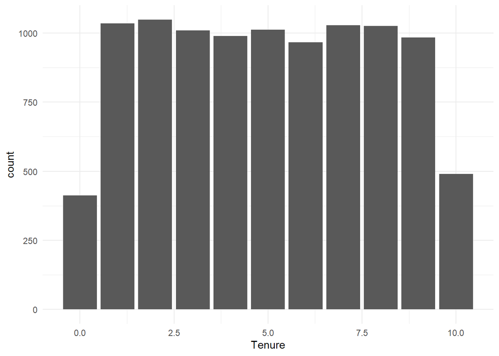

```r
p+geom_bar(mapping =aes(Tenure))+theme_minimal()
```

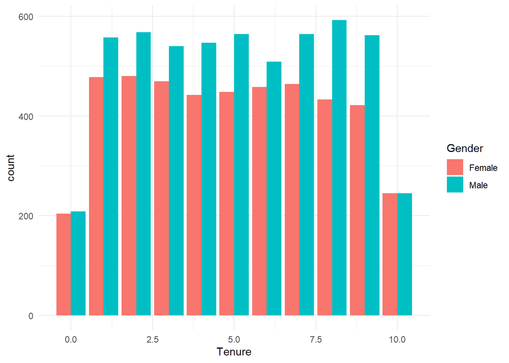

```r
p+geom_bar(mapping =aes(Tenure,fill=Gender),position = 'dodge')+theme_minimal()
```

## Histogramas

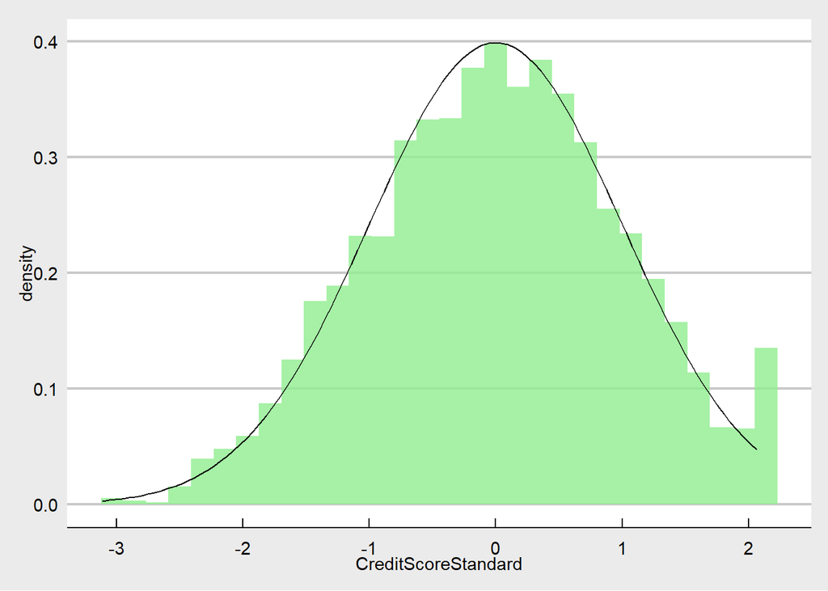

```r
data2['CreditScoreStandard'] <-(data2$CreditScore-mean(data2$CreditScore))/sd(data2$CreditScore)
data2['AgeStandard'] <-(data2$Age-mean(data2$Age))/sd(data2$Age)
data2['BalanceStandard'] <-(data2$Balance-mean(data2$Balance))/sd(data2$Balance)
data2['EstimatedSalaryStandard'] <-(data2$EstimatedSalary-mean(data2$EstimatedSalary))/sd(data2$EstimatedSalary)

data_balance <-filter(data2,Balance != 0)
data_balance['BalanceStandard2'] <-(data_balance$Balance-mean(data_balance$Balance))/sd(data_balance$Balance)

p2 <-ggplot(data2)

p2+geom_histogram(mapping = aes(CreditScoreStandard,y=..density..),fill='lightgreen',alpha=0.8)+stat_function(fun = dnorm)+theme_economist_white()
```

```r
describe(data$CreditScore)
```

```
##    vars     n   mean    sd median trimmed   mad min max range  skew kurtosis
## X1    1 10000 650.53 96.65    652  651.01 99.33 350 850   500 -0.07    -0.43
##      se
## X1 0.97
```

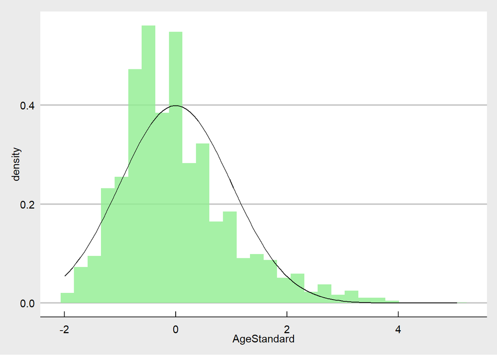

```r
p2+geom_histogram(mapping = aes(AgeStandard,y=..density..),fill='lightgreen',alpha=0.8)+stat_function(fun = dnorm)+theme_economist_white()
```

```r
describe(data$Age)
```

```
##    vars     n  mean    sd median trimmed mad min max range skew kurtosis  se
## X1    1 10000 38.92 10.49     37   37.91 8.9  18  92    74 1.01     1.39 0.1
```

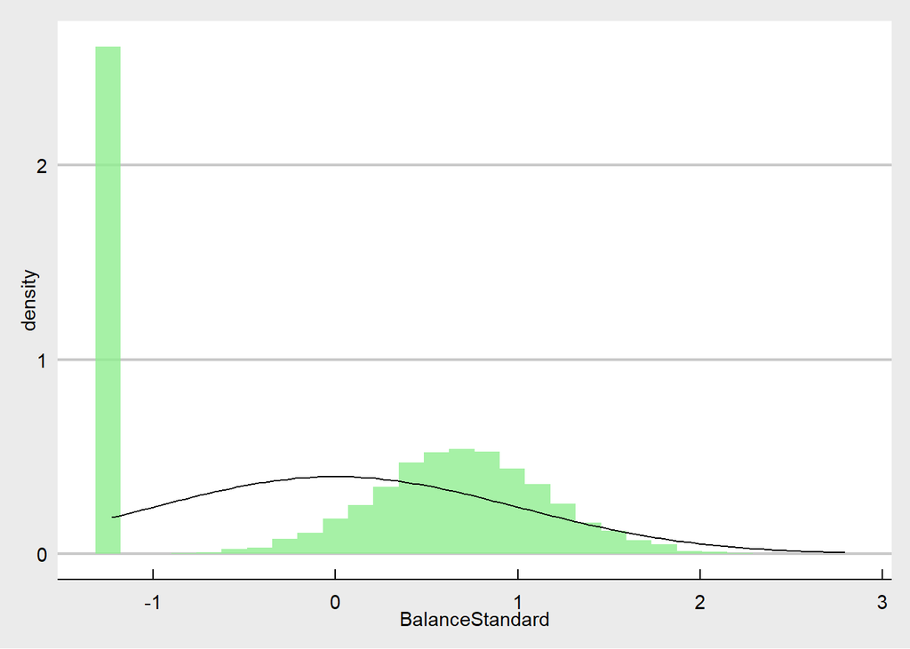

```r
p2+geom_histogram(mapping = aes(BalanceStandard,y=..density..),fill='lightgreen',alpha=0.8)+stat_function(fun = dnorm)+theme_economist_white()
```

```r
describe(data2$Balance)
```

```
##    vars     n     mean       sd   median trimmed      mad min      max    range
## X1    1 10000 76485.89 62397.41 97198.54 74827.8 69336.44   0 250898.1 250898.1
##     skew kurtosis     se
## X1 -0.14    -1.49 623.97
```

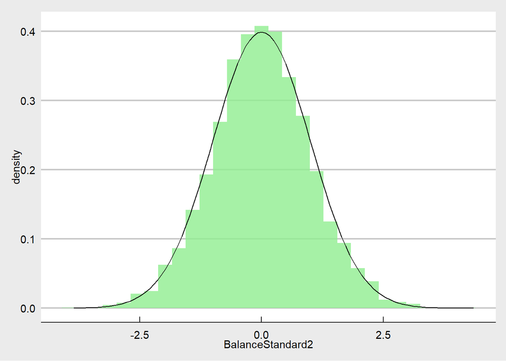

```r
p3 <-ggplot(data_balance)
p3+geom_histogram(mapping = aes(BalanceStandard2,y=..density..),fill='lightgreen',alpha=0.8)+stat_function(fun = dnorm)+theme_economist_white()
```

```r
describe(data_balance$Balance)
```

```
##    vars    n     mean       sd   median  trimmed      mad     min      max
## X1    1 6383 119827.5 30095.06 119839.7 119743.4 29163.01 3768.69 250898.1
##       range skew kurtosis     se
## X1 247129.4 0.03      0.2 376.69
```

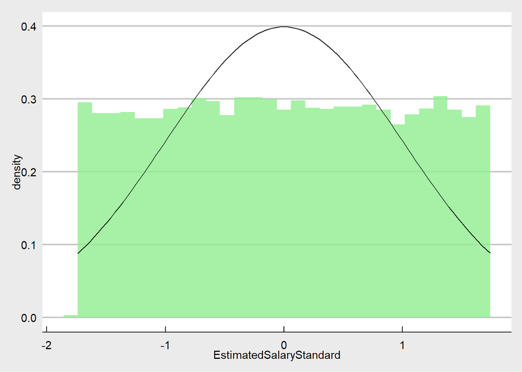

```r
p2+geom_histogram(mapping = aes(EstimatedSalaryStandard,y=..density..),fill='lightgreen',alpha=0.8)+stat_function(fun = dnorm)+theme_economist_white()
```

```r
describe(data$EstimatedSalary)
```

```
##    vars     n     mean       sd   median  trimmed      mad   min      max
## X1    1 10000 100090.2 57510.49 100193.9 100114.9 72941.18 11.58 199992.5
##       range skew kurtosis    se
## X1 199980.9    0    -1.18 575.1
```

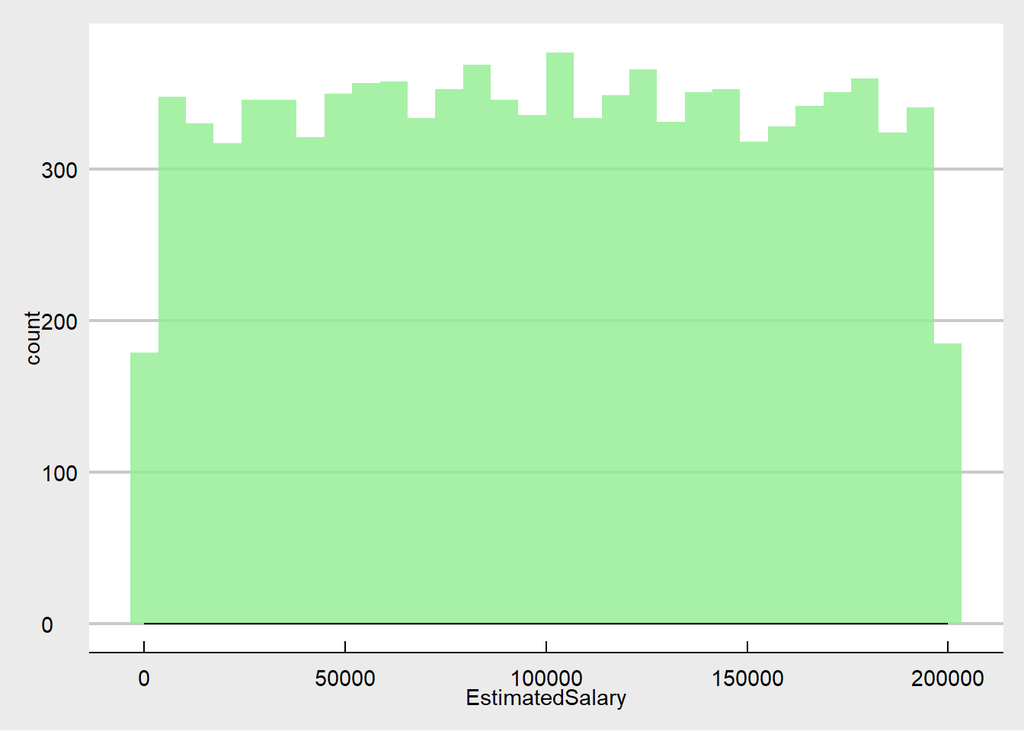

```r
p2+geom_histogram(mapping = aes(EstimatedSalary),fill='lightgreen',alpha=0.8)+stat_function(fun = dnorm)+theme_economist_white()
```

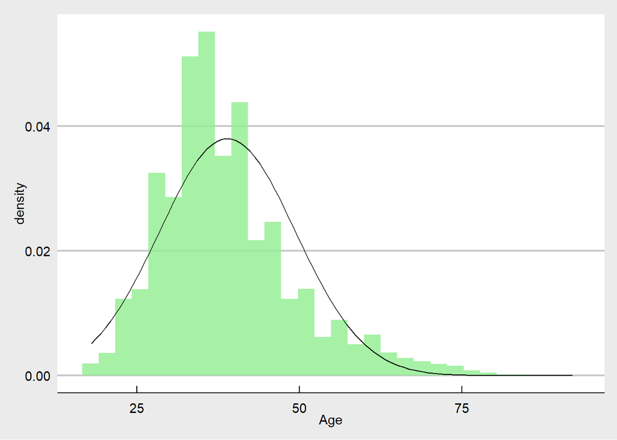

```r
p2+geom_histogram(mapping = aes(Age,y=..density..),fill='lightgreen',alpha=0.8)+stat_function(fun = dnorm, args = list(mean=mean(data2$Age),sd = sd(data2$Age)))+theme_economist_white()
```

```r
describe(data$Age)
```

```
##    vars     n  mean    sd median trimmed mad min max range skew kurtosis  se
## X1    1 10000 38.92 10.49     37   37.91 8.9  18  92    74 1.01     1.39 0.1
```

## BoxPlots

### Boxplot: Credit Score - Geografia y Genero

Se observa que tanto las medianas como el rango intercuatilico para todos los paises y ambos generos es similar, y se pueden ver algunos Outliers en la zona inferior.

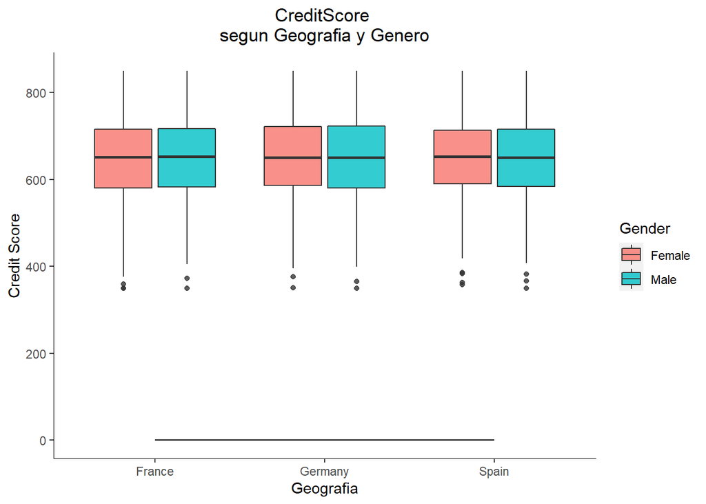

```r
p2+geom_boxplot(mapping = aes(x=Geography,y=CreditScore,fill=Gender),alpha=0.8)+stat_function(fun = dnorm)+theme(plot.title=element_text(hjust = 0.5),panel.background = element_rect(fill="white"),axis.line.y=element_line(colour="black",size=0.2),
        axis.line.x=element_line(colour="black",size=0.2))+labs(title='CreditScore \nsegun Geografia y Genero',y='Credit Score',x='Geografia')
```

```r
by(hombres$CreditScore,hombres$Geography,summary)
```

```
## hombres$Geography: France
##    Min. 1st Qu.  Median    Mean 3rd Qu.    Max.
##   350.0   583.0   653.0   650.1   717.0   850.0
## ------------------------------------------------------------
## hombres$Geography: Germany
##    Min. 1st Qu.  Median    Mean 3rd Qu.    Max.
##   350.0   581.0   650.5   650.0   723.2   850.0
## ------------------------------------------------------------
## hombres$Geography: Spain
##    Min. 1st Qu.  Median    Mean 3rd Qu.    Max.
##     350     584     650     651     716     850
```

```r
by(mujeres$CreditScore,mujeres$Geography,summary)
```

```
## mujeres$Geography: France
##    Min. 1st Qu.  Median    Mean 3rd Qu.    Max.
##   350.0   580.0   652.0   649.2   716.0   850.0
## ------------------------------------------------------------
## mujeres$Geography: Germany
##    Min. 1st Qu.  Median    Mean 3rd Qu.    Max.
##   351.0   587.0   651.0   653.1   722.0   850.0
## ------------------------------------------------------------
## mujeres$Geography: Spain
##    Min. 1st Qu.  Median    Mean 3rd Qu.    Max.
##   358.0   590.0   653.0   651.8   713.0   850.0
```

### Boxplot: Edad - Geografia y Genero

En este caso se observan las medianas tambien son similares entre si para ambos generos, pero que existen una cantidad importante de outliers en la zona superior del grafico, lo que muestra que aunque los datos en su mayoria se acumulan entre los 25 y 50 anos (aprox), existe una dispersion observable.

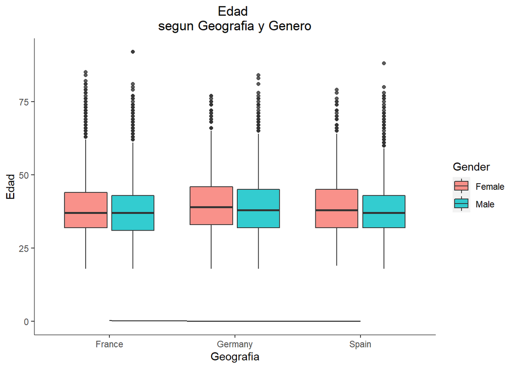

```r
p2+geom_boxplot(mapping = aes(x=Geography,y=Age,fill=Gender),alpha=0.8)+stat_function(fun = dnorm)+theme(plot.title=element_text(hjust = 0.5),panel.background = element_rect(fill="white"),axis.line.y=element_line(colour="black",size=0.2),
        axis.line.x=element_line(colour="black",size=0.2))+labs(title='Edad \nsegun Geografia y Genero',y='Edad',x='Geografia')
```

```r
by(hombres$Age,hombres$Geography,summary)
```

```
## hombres$Geography: France
##    Min. 1st Qu.  Median    Mean 3rd Qu.    Max.
##    18.0    31.0    37.0    38.3    43.0    92.0
## ------------------------------------------------------------
## hombres$Geography: Germany
##    Min. 1st Qu.  Median    Mean 3rd Qu.    Max.
##   18.00   32.00   38.00   39.42   45.00   84.00
## ------------------------------------------------------------
## hombres$Geography: Spain
##    Min. 1st Qu.  Median    Mean 3rd Qu.    Max.
##   18.00   32.00   37.00   38.65   43.00   88.00
```

```r
by(mujeres$Age,mujeres$Geography,summary)
```

```
## mujeres$Geography: France
##    Min. 1st Qu.  Median    Mean 3rd Qu.    Max.
##   18.00   32.00   37.00   38.77   44.00   85.00
## ------------------------------------------------------------
## mujeres$Geography: Germany
##    Min. 1st Qu.  Median    Mean 3rd Qu.    Max.
##   18.00   33.00   39.00   40.15   46.00   77.00
## ------------------------------------------------------------
## mujeres$Geography: Spain
##    Min. 1st Qu.  Median    Mean 3rd Qu.    Max.
##    19.0    32.0    38.0    39.2    45.0    79.0
```

### Boxplot: Balance - Geografia y Genero

Podemos observar que para los casos de Espana y Francia la cantidad de balances en cero es tan importante que desplaza los boxplots hacia el cero, aunque el rango intercuartilico muestra una gran amplitud lo que significa que hay una gran dispersion de los datos. Por el contrario, en el caso de Alemania, se puede ver que los datos se concentran alrededor de la mediana con un rango intercuartilico mas acotado.

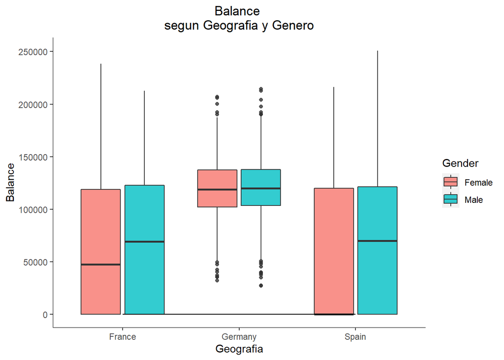

```r
p2+geom_boxplot(mapping = aes(x=Geography,y=Balance,fill=Gender),alpha=0.8)+stat_function(fun = dnorm)+theme(plot.title=element_text(hjust = 0.5),panel.background = element_rect(fill="white"),axis.line.y=element_line(colour="black",size=0.2),
        axis.line.x=element_line(colour="black",size=0.2))+labs(title='Balance \nsegun Geografia y Genero',y='Balance',x='Geografia')
```

```r
by(hombres$Balance,hombres$Geography,summary)
```

```
## hombres$Geography: France
##    Min. 1st Qu.  Median    Mean 3rd Qu.    Max.
##       0       0   69413   63546  122807  212693
## ------------------------------------------------------------
## hombres$Geography: Germany
##    Min. 1st Qu.  Median    Mean 3rd Qu.    Max.
##   27288  103398  120120  120260  137815  214347
## ------------------------------------------------------------
## hombres$Geography: Spain
##    Min. 1st Qu.  Median    Mean 3rd Qu.    Max.
##       0       0   69857   63353  121348  250898
```

```r
by(mujeres$Balance,mujeres$Geography,summary)
```

```
## mujeres$Geography: France
##    Min. 1st Qu.  Median    Mean 3rd Qu.    Max.
##       0       0   47536   60323  119014  238388
## ------------------------------------------------------------
## mujeres$Geography: Germany
##    Min. 1st Qu.  Median    Mean 3rd Qu.    Max.
##   32198  102287  118908  119146  137327  206869
## ------------------------------------------------------------
## mujeres$Geography: Spain
##    Min. 1st Qu.  Median    Mean 3rd Qu.    Max.
##       0       0       0   59862  119799  216110
```

### Boxplot: Salario Estimado - Geografia y Genero

Nuevamente en este grafico se observa una distribucion pareja de los datos, es decir, en todos los casos los datos se distribuyen practicamente de forma homogenea alrededor de la mediana con un rango intercuartilico amplio y con bigotes entre los maximos y minimos de cada uno de los datos, y gracias a esta distribucion no se observan Outliers en el grafico.

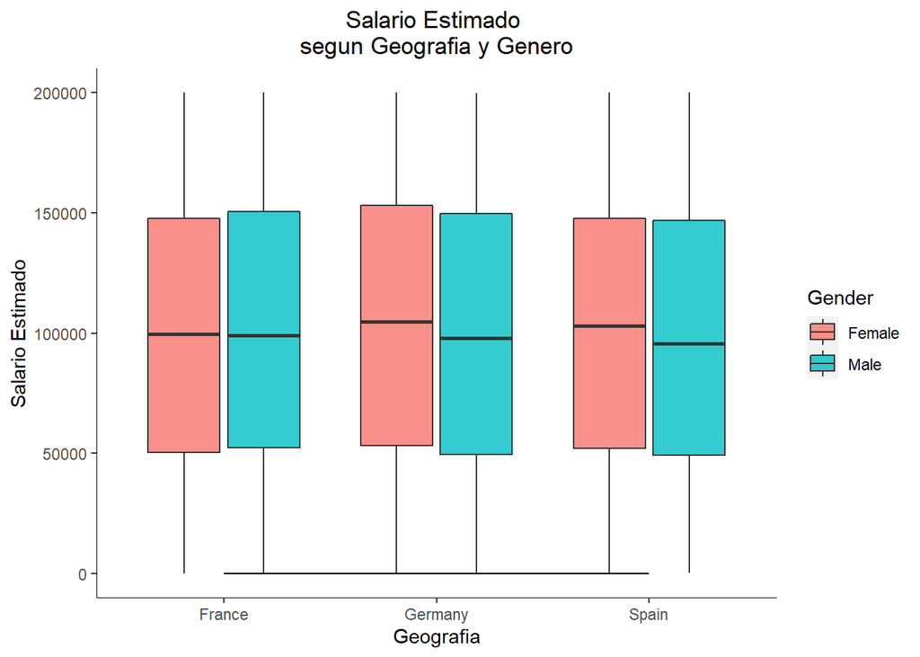

```r
p2+geom_boxplot(mapping = aes(x=Geography,y=EstimatedSalary,fill=Gender),alpha=0.8)+stat_function(fun = dnorm)+theme(plot.title=element_text(hjust = 0.5),panel.background = element_rect(fill="white"),axis.line.y=element_line(colour="black",size=0.2),
        axis.line.x=element_line(colour="black",size=0.2))+labs(title='Salario Estimado \nsegun Geografia y Genero',y='Salario Estimado',x='Geografia')
```

```r
by(hombres$EstimatedSalary,hombres$Geography,summary)
```

```
## hombres$Geography: France
##      Min.   1st Qu.    Median      Mean   3rd Qu.      Max.
##     90.07  52525.15  99017.34 100174.25 150468.35 199929.17
## ------------------------------------------------------------
## hombres$Geography: Germany
##      Min.   1st Qu.    Median      Mean   3rd Qu.      Max.
##     11.58  49601.94  97892.70  99905.03 149590.84 199693.84
## ------------------------------------------------------------
## hombres$Geography: Spain
##     Min.  1st Qu.   Median     Mean  3rd Qu.     Max.
##    417.4  49179.5  95672.4  98425.7 146773.1 199953.3
```

```r
by(mujeres$EstimatedSalary,mujeres$Geography,summary)
```

```
## mujeres$Geography: France
##     Min.  1st Qu.   Median     Mean  3rd Qu.     Max.
##    178.2  50457.2  99504.0  99564.2 147545.6 199862.8
## ------------------------------------------------------------
## mujeres$Geography: Germany
##      Min.   1st Qu.    Median      Mean   3rd Qu.      Max.
##     91.75  53217.30 104617.99 102446.42 153012.13 199970.74
## ------------------------------------------------------------
## mujeres$Geography: Spain
##     Min.  1st Qu.   Median     Mean  3rd Qu.     Max.
##    479.5  52138.5 102889.3 100734.1 147606.7 199992.5
```

3. Llevar a cabo un analisis estadistico en R y saber interpretar los resultados.

Para dicho analisis, el alumno/a podra elegir entre las dos siguientes opciones: a) Realizar un analisis de comparacion, siendo la hipotesis inicial: “el salario de los consumidores es igual en los diferentes paises donde se han recogido los datos” b) Realizar un analisis de relacion, siendo la hipotesis inicial: “la edad predice la solvencia (credit score) de los consumidores” opcional: en cualquiera de las elecciones se podra incluir covariables para realizar un analisis mas completo (justificar la eleccion e incluir en la interpretacion de los resultados) Pautas para el analisis:

- ¿Cual es la hipotesis nula y la hipotesis alternativa?
- ¿Que analisis es correcto para testar dicha hipotesis? ¿Por qué?
- Mostrar los resultados y representarlos graficamente
- Interpretar los resultados
- Sacar conclusiones en base a los resultados obtenidos y en relacion con la hipotesis inicial.

### Opcion B: Analisis de Hipotesis.

```r
describe(data$Age)
```

```
##    vars     n  mean    sd median trimmed mad min max range skew kurtosis  se
## X1    1 10000 38.92 10.49     37   37.91 8.9  18  92    74 1.01     1.39 0.1
```

```r
summary(data$Age)
```

```
##    Min. 1st Qu.  Median    Mean 3rd Qu.    Max.
##   18.00   32.00   37.00   38.92   44.00   92.00
```

```r
describe(data$CreditScore)
```

```
##    vars     n   mean    sd median trimmed   mad min max range  skew kurtosis
## X1    1 10000 650.53 96.65    652  651.01 99.33 350 850   500 -0.07    -0.43
##      se
## X1 0.97
```

```r
summary(data$CreditScore)
```

```
##    Min. 1st Qu.  Median    Mean 3rd Qu.    Max.
##   350.0   584.0   652.0   650.5   718.0   850.0
```

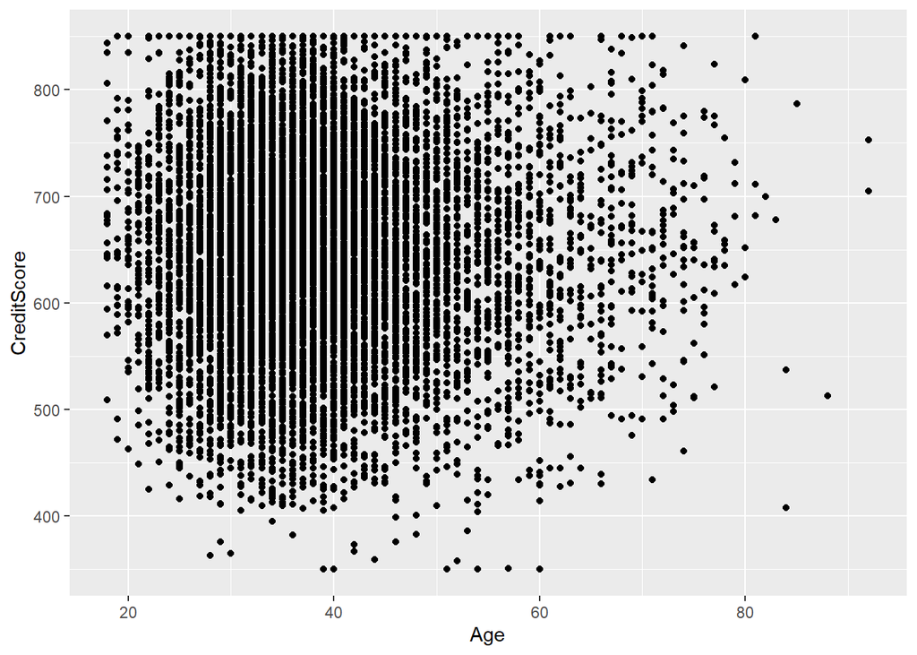

```r
p+geom_point(mapping = aes(Age,CreditScore))
```

```r
cor.test(data$Age,data$CreditScore)
```

```
##
##  Pearson's product-moment correlation
##
## data:  data$Age and data$CreditScore
## t = -0.39645, df = 9998, p-value = 0.6918
## alternative hypothesis: true correlation is not equal to 0
## 95 percent confidence interval:
##  -0.02356314  0.01563638
## sample estimates:
##          cor
## -0.003964906
```

```r
lineal <-lm(data$CreditScore~data$Age)
summary(lm(data$CreditScore~data$Age))
```

```
##
## Call:
## lm(formula = data$CreditScore ~ data$Age)
##
## Residuals:
##      Min       1Q   Median       3Q      Max
## -300.526  -66.785    1.358   67.045  201.009
##
## Coefficients:
##              Estimate Std. Error t value Pr(>|t|)
## (Intercept) 651.95099    3.71522 175.481   <2e-16 ***
## data$Age     -0.03654    0.09217  -0.396    0.692
## ---
## Signif. codes:  0 '***' 0.001 '**' 0.01 '*' 0.05 '.' 0.1 ' ' 1
##
## Residual standard error: 96.66 on 9998 degrees of freedom
## Multiple R-squared:  1.572e-05,  Adjusted R-squared:  -8.43e-05
## F-statistic: 0.1572 on 1 and 9998 DF,  p-value: 0.6918
```

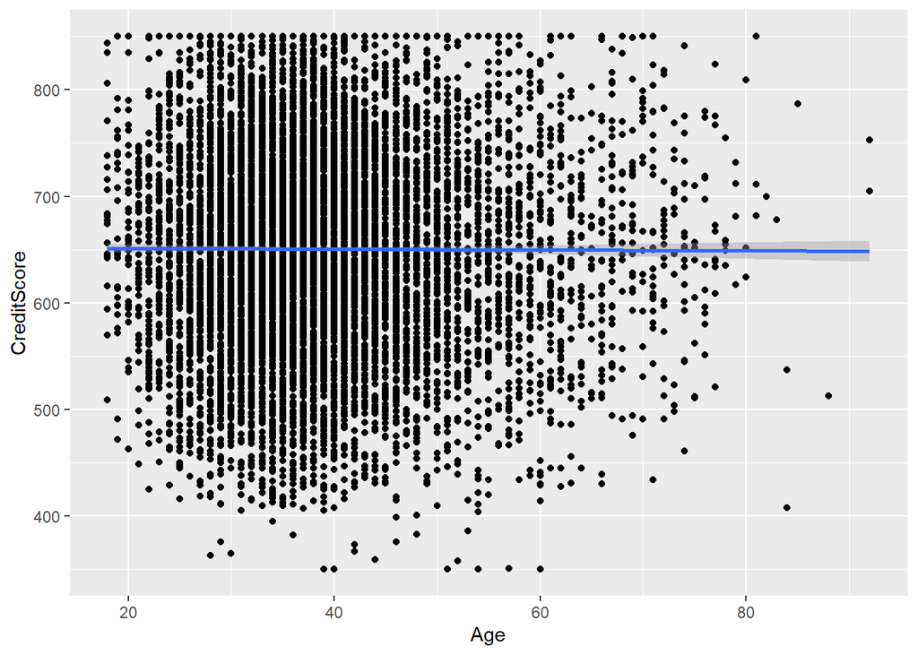

```r
p+geom_point(mapping = aes(Age,CreditScore))+geom_smooth(mapping=aes(Age,CreditScore),method = 'lm')
```

```r
#Linealidad : Con el Cor.Test.
#Normalidad
library(DescTools)
```

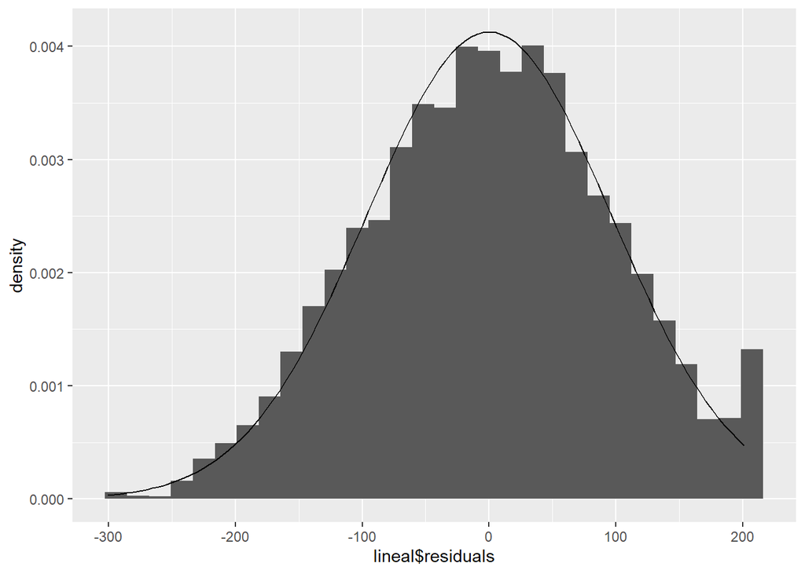

```r
g <- ggplot(lineal)
g+geom_histogram(mapping = aes(lineal$residuals, y=..density..))+stat_function(fun = dnorm, args = list(mean=mean(lineal$residuals),sd = sd(lineal$residuals)))
```

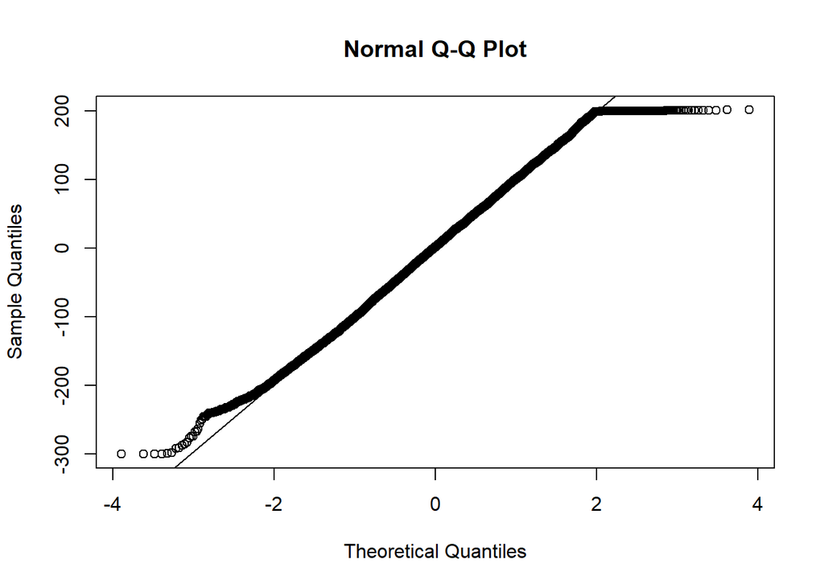

```r
qqnorm(lineal$residuals);qqline(lineal$residuals)
```

```r
ks.test(lineal$residuals,pnorm)
```

```
##
##  One-sample Kolmogorov-Smirnov test
##
## data:  lineal$residuals
## D = 0.49209, p-value < 2.2e-16
## alternative hypothesis: two-sided
```

```r
LillieTest(lineal$residuals)
```

```
##
##  Lilliefors (Kolmogorov-Smirnov) normality test
##
## data:  lineal$residuals
## D = 0.018776, p-value = 1.983e-08
```

```r
describe(lineal$residuals)
```

```
##    vars     n mean    sd median trimmed   mad     min    max  range  skew
## X1    1 10000    0 96.65   1.36    0.48 99.32 -300.53 201.01 501.53 -0.07
##    kurtosis   se
## X1    -0.43 0.97
```

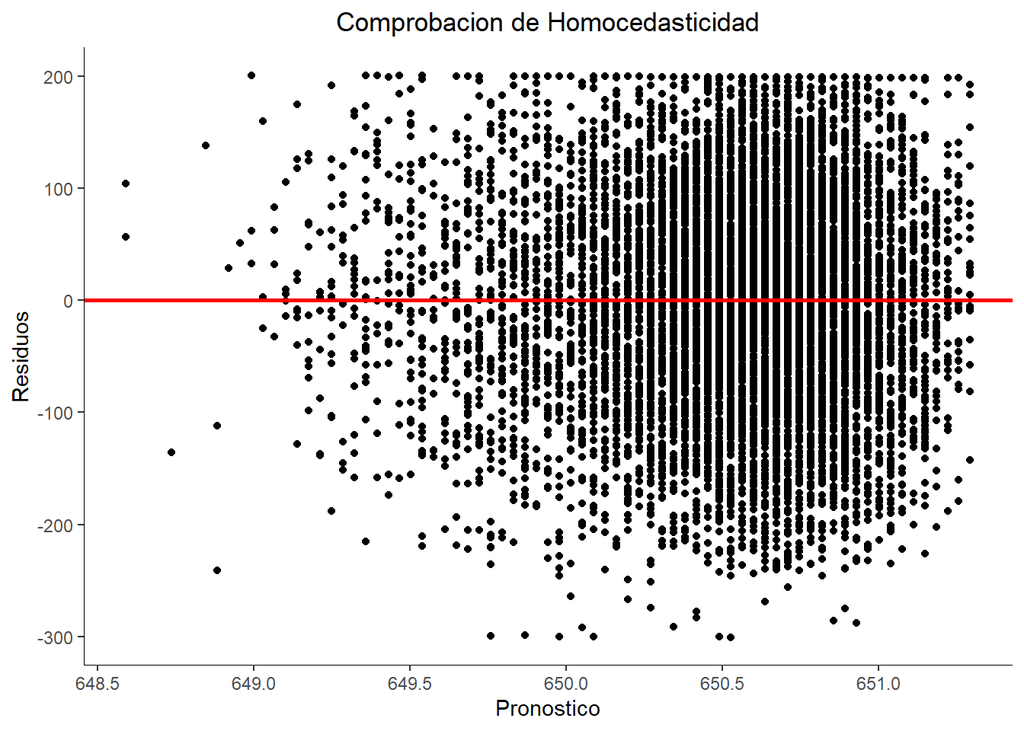

```r
#Homocedasticidad
g+geom_point(mapping =aes(x=lineal$fitted.values,y=lineal$residuals))+geom_hline(aes(yintercept = 0),color = 'Red',size=1)+theme(plot.title=element_text(hjust = 0.5),panel.background = element_rect(fill="white"),axis.line.y=element_line(colour="black",size=0.2),
        axis.line.x=element_line(colour="black",size=0.2))+labs(title = 'Comprobacion de Homocedasticidad',x='Pronostico',y='Residuos')
```

```r
#Independencia
DurbinWatsonTest(lineal)
```

```
##
##  Durbin-Watson test
##
## data:  lineal
## DW = 2.0139, p-value = 0.7569
## alternative hypothesis: true autocorrelation is greater than 0
```

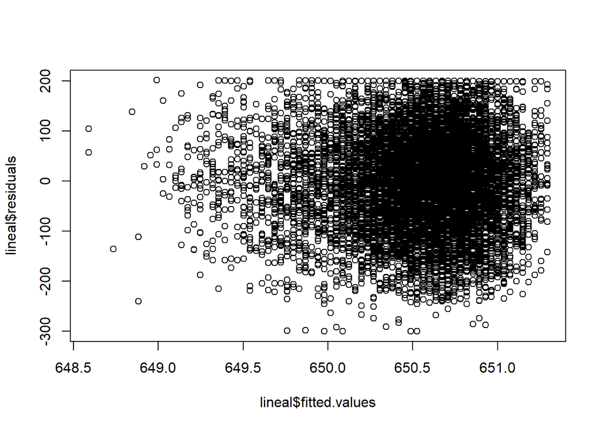

```r
plot(lineal$fitted.values,lineal$residuals)
```

```r
# No usar el p_value para interpretar. Esta bien. Son independientes.
```

Respondiendo las preguntas: La hipotesis nula seria que la edad NO predice la solvencia economica (CreditScore), esto se traduce en que la correlacion lineal o B1 es igual a 0. Por otra parte, la hipotesis alternativa seria que la edad si predice (hasta cierto punto) la solvencia economica (CreditScore). Para testear dichas hipotesis se procedio a realizar un analisis estadistico de regresion lineal, basandonos en los supuestos de linealidad, normalidad, homocedasticidad e independencia que dicha regresion requiere para ser aplicada. Como conclusion, a partir de los resultados obtenidos, podemos afirmar que no hay una relacion lineal entre la edad y la solvencia economica, y por lo tanto no es posible predecir una en funcion de la otra.

```r
data_france_Spain <- filter(data,data$Geography!='Germany')
t.test(data_france_Spain$EstimatedSalary~data_france_Spain$Geography ,var.equal=T)
```

```
##
##  Two Sample t-test
##
## data:  data_france_Spain$EstimatedSalary by data_france_Spain$Geography
## t = 0.32612, df = 7489, p-value = 0.7443
## alternative hypothesis: true difference in means is not equal to 0
## 95 percent confidence interval:
##  -2298.034  3215.251
## sample estimates:
## mean in group France  mean in group Spain
##             99899.18             99440.57
```

```r
data_france_Germany <- filter(data,data$Geography!='Spain')
t.test(data_france_Germany$EstimatedSalary~data_france_Germany$Geography ,var.equal=T)
```

```
##
##  Two Sample t-test
##
## data:  data_france_Germany$EstimatedSalary by data_france_Germany$Geography
## t = -0.86135, df = 7521, p-value = 0.3891
## alternative hypothesis: true difference in means is not equal to 0
## 95 percent confidence interval:
##  -3977.678  1549.170
## sample estimates:
##  mean in group France mean in group Germany
##              99899.18             101113.44
```

```r
data_germany_Spain <- filter(data,data$Geography!='France')
t.test(data_germany_Spain$EstimatedSalary~data_germany_Spain$Geography ,var.equal=T)
```

```
##
##  Two Sample t-test
##
## data:  data_germany_Spain$EstimatedSalary by data_germany_Spain$Geography
## t = 1.0238, df = 4984, p-value = 0.306
## alternative hypothesis: true difference in means is not equal to 0
## 95 percent confidence interval:
##  -1530.578  4876.304
## sample estimates:
## mean in group Germany   mean in group Spain
##             101113.44              99440.57
```